# Large language models and human crowds make the same prediction errors — analysis and verification report

Live Leonhardsen Wilhelmsen, Roya Esfandiari & Anton Gollwitzer

3 September 2026

# About this document

This report accompanies our Matters Arising on Ashokkumar, Hewitt, Ghezae & Willer, *Large language models can predict the results of social science experiments* (Nature, 2026), https://doi.org/10.1038/s41586-026-10742-x. It computes every quantity reported in the commentary and its Supplementary Information, in the order of the Supplementary Information, and ends with a **verification ledger**: a table listing each number quoted in the manuscript next to the value computed in this render. The document refuses to knit if any quoted value fails to reproduce.

Code is folded by default; the *Code* buttons unfold any chunk. All random components use fixed seeds, set at the top of the chunk that uses them.

**Three ways to use this document.**

1. *Read it.* The rendered HTML contains every number and figure; no software is required.
2. *Re-render it from the deposited data.* The comparison-level tables in `data/derived/` are included in this repository (CC BY 4.0). Knitting the document from them reproduces every reported value in roughly ten minutes: `rmarkdown::render("docs/analysis_report.Rmd")`.
3. *Re-render it from the raw data.* The raw files are **not redistributed here**; they are available in Code Ocean capsule 9843791, released with the original Article. With those files placed in `data/raw/` (see `data/raw/README.md`), the additional chunks below rebuild the comparison-level tables from scratch and verify that they are identical to the deposit.

The document locates its data automatically: the repository layout (`data/derived/`, `data/raw/`), a folder named `Original data` next to the document, or the document’s own folder — and `params$data_dir` overrides the search, so a standalone copy of this file knits anywhere as long as the three comparison-level tables are nearby.

The numbered scripts in `R/` run the same analyses as a pipeline (`Rscript run_all.R`); this document is the self-contained, readable version. In this render, the capsule files are present, so the rebuild-and-verify chunks run.

# Data (Supplementary Methods 1.1)

The deposited comparison-level tables are the working data for everything below: one row per condition comparison, with the observed effect, its standard error, and each predictor’s raw and recalibrated standardized errors.

```r
cat("Comparison-level tables found in:", derived_dir, "\n")
```

```
## Comparison-level tables found in: /tmp/repo/data/derived
```

```r
wide <- read.csv(file.path(derived_dir, "comparisons_primary.csv"),
                 check.names = FALSE, encoding = "UTF-8")
all_models <- read.csv(file.path(derived_dir, "comparisons_all_models.csv"),
                       check.names = FALSE, encoding = "UTF-8")

c(comparisons         = nrow(wide),
  studies             = n_distinct(wide$study),
  study_outcome_cells = wide %>% distinct(study, outcome.name) %>% nrow())
```

```
##         comparisons             studies study_outcome_cells
##                1678                  70                 129
```

The raw-data counts reported in Supplementary Methods 1.1 require the capsule files and are computed here when those are present.

```r
rct <- readRDS(file.path(raw_dir, "rct_responses.RDS"))
llm <- readRDS(file.path(raw_dir, "llm_responses.RDS"))
fc  <- readRDS(file.path(raw_dir, "forecasting_responses.RDS"))

c(rct_responses      = sum(map_int(rct$data, nrow)),
  answers_nonmissing = sum(map_int(rct$data, ~sum(!is.na(.x$y)))),
  studies_raw        = n_distinct(rct$study),
  study_outcome_cells_raw = nrow(rct),
  llm_rows           = nrow(llm),
  llm_rows_per_model = nrow(llm) / n_distinct(llm$model),
  forecast_rows      = nrow(fc),
  forecasters        = n_distinct(fc$PROLIFIC_PID))
```

```
##           rct_responses      answers_nonmissing             studies_raw
##                  233601                  229154                      71
## study_outcome_cells_raw                llm_rows      llm_rows_per_model
##                     134                  504840                   72120
##           forecast_rows             forecasters
##                   18317                    2838
```

```r
## the remaining descriptive counts quoted in Supplementary Methods 1.1
per_cell       <- fc %>% count(study, outcome.name, condition.name)
per_forecaster <- fc %>% group_by(PROLIFIC_PID) %>%
  summarise(conditions = n_distinct(study, outcome.name, condition.name),
            studies    = n_distinct(study), .groups = "drop")
c(median_forecasts_per_cell    = median(per_cell$n),
  median_conditions_per_person = median(per_forecaster$conditions),
  forecasters_in_multiple_experiments = sum(per_forecaster$studies > 1),
  prompt_cells_240   = llm %>% count(model, study, outcome.name, condition.name) %>%
                         filter(model == "gpt-4", n == 240) %>% nrow(),
  possible_pairs     = rct %>% pmap_int(function(data, ...) {
                         k <- n_distinct(data$condition.name)
                         as.integer(k * (k - 1) / 2) }) %>% sum())
```

```
##           median_forecasts_per_cell        median_conditions_per_person
##                                  29                                   4
## forecasters_in_multiple_experiments                    prompt_cells_240
##                                   3                                   3
##                      possible_pairs
##                                1705
```

# From raw data to the comparison table (Supplementary Methods 1.2–1.3)

The chunks in this section document the full construction: observed effects from the participant-level responses, predicted effects from the forecast condition means, one row per unordered comparison, and the authors’ leave-one-study-out linear recalibration. They execute when the capsule files are present and finish by verifying that the rebuilt table matches the deposited `comparisons_primary.csv` exactly. The analyses in the rest of the document run from the deposited table either way.

**Observed effects.** Within each study and outcome, responses are rescaled to 0–1 using the bounds of the outcome scale, and every pairwise difference between conditions is estimated by ordinary least squares, retaining the estimate and its standard error. Condition names are recoded to plain ASCII before the regression and mapped back afterwards: some names contain typographic quotes, which R on a non-UTF-8 locale silently rewrites inside coefficient names, and the recode makes the construction identical on any machine.

```r
rct_effects <- rct %>%
  pmap_dfr(function(study, outcome.name, outcome.min, outcome.max, data, ...) {
    d <- data %>% ungroup() %>%
      mutate(y = (as.numeric(y) - outcome.min) / (outcome.max - outcome.min))
    conds <- unique(d$condition.name)
    code  <- setNames(paste0("k", seq_along(conds)), conds)
    d$cc  <- code[d$condition.name]
    map_dfr(conds, function(ref) {
      fit <- lm(y ~ cc, data = d %>% mutate(cc = forcats::fct_relevel(cc, code[[ref]])))
      broom::tidy(fit) %>%
        transmute(cc = str_match(term, "^cc(k\\d+)$")[, 2], estimate, std.error) %>%
        filter(!is.na(cc)) %>%
        mutate(condition.name = names(code)[match(cc, code)],
               study = study, outcome.name = outcome.name,
               reference_condition = ref, .before = 1) %>%
        select(-cc)
    })
  })
```

**Predicted effects.** For each language model, the predicted mean of a condition is the weighted average of its prompt-level responses, using the authors’ demographic weights; reversed answer scales are un-flipped first, following their code. For the human crowd, the predicted mean is the unweighted average of the individual forecasts. A predicted effect is the difference between the predicted means of the two conditions.

```r
llm_means <- llm %>%
  mutate(expectation = ifelse(scale_flip, outcome_scale_max - (expectation - outcome_scale_min),
                              expectation),
         y = (expectation - outcome_scale_min) / (outcome_scale_max - outcome_scale_min)) %>%
  filter(!is.na(y)) %>%
  group_by(model, study, outcome.name, condition.name) %>%
  summarise(pred_mean = weighted.mean(y, w = weight), .groups = "drop")

fc_means <- fc %>%
  mutate(y = value / 100) %>%
  semi_join(distinct(llm, study, outcome.name), by = c("study", "outcome.name")) %>%
  group_by(study, outcome.name, condition.name) %>%
  summarise(pred_mean = mean(y), .groups = "drop") %>%
  mutate(model = "human")

pred_contrasts <- bind_rows(llm_means, fc_means) %>%
  group_by(model, study, outcome.name) %>%
  group_modify(function(d, k) {
    crossing(d %>% select(condition.name, pred_mean),
             d %>% select(reference_condition = condition.name, ref_mean = pred_mean)) %>%
      filter(condition.name != reference_condition) %>%
      transmute(condition.name, reference_condition, prediction = pred_mean - ref_mean)
  }) %>%
  ungroup()
```

**One row per comparison, and the combined predictor.** Comparing A with B and B with A is the same comparison with the sign flipped, so each unordered pair is kept once. The direction of each pair is fixed by ordering condition names with a fixed ICU collator (English): ordering with `<` depends on the computer’s locale — in a plain C locale, R returns `NA` for names with typographic quotes and silently drops those comparisons — whereas the ICU ordering is identical on every machine and matches the orientation of the deposited dataset. The authors’ proposed combination of model and crowd is the arithmetic mean of the two predictions, built the same way so it can be tested below.

```r
en <- stringi::stri_opts_collator(locale = "en_US")
comparisons_built <- rct_effects %>%
  inner_join(pred_contrasts,
             by = c("study", "outcome.name", "condition.name", "reference_condition")) %>%
  filter(stringi::stri_cmp_lt(reference_condition, condition.name, opts_collator = en))

combined_built <- comparisons_built %>%
  filter(model %in% c("gpt-4", "human")) %>%
  select(study, outcome.name, condition.name, reference_condition,
         estimate, std.error, model, prediction) %>%
  pivot_wider(names_from = model, values_from = prediction) %>%
  filter(!is.na(`gpt-4`), !is.na(human)) %>%
  mutate(model = "combined", prediction = (`gpt-4` + human) / 2) %>%
  select(-`gpt-4`, -human)

comparisons_built <- bind_rows(comparisons_built, combined_built)
```

**Recalibration.** Because the raw predictions systematically overstate effect magnitudes, each predictor is recalibrated with the authors’ leave-one-study-out linear procedure, which they used for their pilot-testing analysis: for each study, `estimate ~ prediction` is fitted on the other 69 studies and applied to the held-out study, so no study contributes to its own recalibration. Each prediction error is then expressed in units of the observed effect’s standard error, and a prediction is classified as a miss when it differs from the observed effect by more than 1.96 standard errors.

```r
comparisons_built <- comparisons_built %>%
  mutate(z_raw = (prediction - estimate) / std.error) %>%
  group_by(model) %>%
  group_modify(function(d, k) {
    d$pred_recal <- NA_real_
    for (s in unique(d$study)) {
      fit <- lm(estimate ~ prediction, data = d %>% filter(study != s))
      d$pred_recal[d$study == s] <- predict(fit, newdata = d %>% filter(study == s))
    }
    d
  }) %>%
  ungroup() %>%
  mutate(z_recal = (pred_recal - estimate) / std.error)

wide_built <- comparisons_built %>%
  filter(model %in% c("gpt-4", "human", "combined")) %>%
  select(study, outcome.name, reference_condition, condition.name,
         estimate, std.error, model, z_recal) %>%
  pivot_wider(names_from = model, values_from = z_recal) %>%
  filter(!is.na(`gpt-4`), !is.na(human))
```

```r
## the deposited table is identical to the rebuild
m <- inner_join(
  wide_built %>% transmute(study, outcome.name, reference_condition, condition.name,
                           zg_built = `gpt-4`, zh_built = human, zc_built = combined),
  wide %>% select(study, outcome.name, reference_condition, condition.name, zg, zh, zc),
  by = c("study", "outcome.name", "reference_condition", "condition.name"))
stopifnot(nrow(m) == nrow(wide), nrow(m) == nrow(wide_built),
          max(abs(m$zg_built - m$zg)) < 1e-8,
          max(abs(m$zh_built - m$zh)) < 1e-8,
          max(abs(m$zc_built - m$zc)) < 1e-8)
cat("Rebuilt table matches the deposited comparisons_primary.csv:",
    nrow(m), "comparisons, maximum |difference| <", 1e-8, "\n")
```

```
## Rebuilt table matches the deposited comparisons_primary.csv: 1678 comparisons, maximum |difference| < 1e-08
```

# Miss rates and recalibration summary (Supplementary Methods 1.3)

```r
miss_g <- abs(wide$zg) > 1.96
miss_h <- abs(wide$zh) > 1.96

## pooled recalibration lines (the leave-one-study-out fits vary only slightly
## around these); pg and ph are the unrecalibrated predicted effects
recal_lines <- bind_rows(
  broom::tidy(lm(estimate ~ pg, data = wide)) %>% mutate(model = "gpt-4"),
  broom::tidy(lm(estimate ~ ph, data = wide)) %>% mutate(model = "human")) %>%
  transmute(model, term = ifelse(grepl("Intercept", term), "intercept", "slope"),
            estimate = round(estimate, 3))
recal_lines
```

```
## # A tibble: 4 × 3
##   model term      estimate
##   <chr> <chr>        <dbl>
## 1 gpt-4 intercept   -0.001
## 2 gpt-4 slope        0.551
## 3 human intercept    0
## 4 human slope        0.616
```

```r
c(miss_gpt4_raw     = round(mean(abs(wide$zg_raw) > 1.96), 3),
  miss_crowd_raw    = round(mean(abs(wide$zh_raw) > 1.96), 3),
  miss_gpt4_recal   = round(mean(miss_g), 3),
  miss_crowd_recal  = round(mean(miss_h), 3))
```

```
##    miss_gpt4_raw   miss_crowd_raw  miss_gpt4_recal miss_crowd_recal
##            0.463            0.498            0.357            0.380
```

# The headline result (main text)

Across the 1,678 comparisons, the two predictors’ misses coincide — and point the same way — far more often than unrelated predictors would.

```r
joint <- miss_g & miss_h
same  <- joint & (sign(wide$zg) == sign(wide$zh))

tibble(
  `Joint misses`      = sum(joint),
  `Joint rate`        = mean(joint),
  `Same-side misses`  = sum(same),
  `Same-side rate`    = mean(same),
  `Direction | joint` = sum(same) / sum(joint)
) %>% mutate(across(where(is.numeric), ~round(., 3))) %>% as.data.frame()
```

```
##   Joint misses Joint rate Same-side misses Same-side rate Direction | joint
## 1          339      0.202              305          0.182               0.9
```

**The combined predictor.** The authors propose averaging model and crowd. The average was built and recalibrated identically above, so its behaviour on the joint misses can be read off directly: averaging repairs opposite-side misses and leaves same-side misses in place.

```r
comb <- c(
  recovers_opposite_side = mean(abs(wide$zc[joint & !same]) <= 1.96),
  still_outside_same_side = mean(abs(wide$zc[same]) > 1.96))
round(comb, 3)
```

```
##  recovers_opposite_side still_outside_same_side
##                   0.824                   0.954
```

# The corrected null (Supplementary Methods 1.4)

Some same-direction overlap is expected even between independent predictors, because both are scored against the same estimated effect, which carries sampling noise of its own. Writing each standardized error as $z_i = a_i - u$, where $a_i$ is the predictor’s own deviation from the true effect and $u$ is the estimate’s standardized sampling noise — shared by both predictors, with variance 1 by construction — the corrected null treats the two predictors as independent while retaining the shared $u$, with each predictor’s spread calibrated so that its overall miss rate matches the observed one. Under this null the pair of errors is bivariate normal, so every benchmark is a one-dimensional integral and carries no simulation noise.

```r
null_exact <- function(miss_g, miss_h, t = 1.96) {
  sig <- function(p) t / qnorm(1 - p / 2)            # total sd yielding this miss rate
  s2g <- max(sig(miss_g)^2 - 1, 0); s2h <- max(sig(miss_h)^2 - 1, 0)
  tail_hi <- function(s2, u) if (s2 > 0) pnorm((t + u) / sqrt(s2), lower.tail = FALSE) else as.numeric(-u >  t)
  tail_lo <- function(s2, u) if (s2 > 0) pnorm((-t + u) / sqrt(s2))                    else as.numeric(-u < -t)
  f <- function(u, kind) sapply(u, function(uu) {
    gh <- tail_hi(s2g, uu); gl <- tail_lo(s2g, uu)
    hh <- tail_hi(s2h, uu); hl <- tail_lo(s2h, uu)
    v <- if (kind == "joint") (gh + gl) * (hh + hl) else gh * hh + gl * hl
    v * dnorm(uu)
  })
  joint <- integrate(f, -9, 9, kind = "joint", rel.tol = 1e-9, subdivisions = 500L)$value
  same  <- integrate(f, -9, 9, kind = "same",  rel.tol = 1e-9, subdivisions = 500L)$value
  c(joint = joint, same = same, direction = same / joint)
}
ne <- null_exact(mean(miss_g), mean(miss_h))
round(100 * ne, 2)
```

```
##     joint      same direction
##     14.09     10.03     71.17
```

```r
## the naive benchmark that ignores the shared estimate
c(naive_same_side = round(mean(miss_g) * mean(miss_h) / 2, 3), naive_direction = 0.5)
```

```
## naive_same_side naive_direction
##           0.068           0.500
```

A direct simulation of the same null verifies the integral and provides the calibrated spreads reused by the exceedance tests below.

```r
set.seed(2)
N <- 2e6
u <- rnorm(N); bg <- rnorm(N); bh <- rnorm(N)
calib <- function(b, target)
  uniroot(function(s) mean(abs(s * b - u) > 1.96) - target, c(0.05, 20))$root
sg <- calib(bg, mean(miss_g)); sh <- calib(bh, mean(miss_h))
zgs <- sg * bg - u; zhs <- sh * bh - u
joint_s <- abs(zgs) > 1.96 & abs(zhs) > 1.96
same_s  <- joint_s & sign(zgs) == sign(zhs)
c(null_joint = round(mean(joint_s), 3),
  null_same  = round(mean(same_s), 3),
  null_direction = round(mean(sign(zgs[joint_s]) == sign(zhs[joint_s])), 3),
  E_zg_zh = round(mean(zgs * zhs), 3))   # theory: exactly Var(u) = 1 under this null
```

```
##     null_joint      null_same null_direction        E_zg_zh
##          0.141          0.100          0.712          1.002
```

**Sensitivity to the normality of the null.** The predictors’ real errors have heavier tails than a normal distribution, so the two decisive benchmarks are recomputed exactly under heavier-tailed error shapes — a Student t with 3 degrees of freedom, and the empirical shape of the errors themselves. Heavier tails lower the benchmarks slightly, so the normal specification reported in the manuscript is the most conservative.

```r
null_exact_tail <- function(miss_g, miss_h, t = 1.96, ptail) {
  miss_of <- function(s) integrate(function(u) sapply(u, function(uu)
      (ptail((t + uu) / s) + ptail((t - uu) / s)) * dnorm(uu)), -9, 9,
      subdivisions = 500L, stop.on.error = FALSE)$value
  cal <- function(p) uniroot(function(s) miss_of(s) - p, c(0.05, 30))$root
  sg <- cal(miss_g); sh <- cal(miss_h)
  f <- function(u, kind) sapply(u, function(uu) {
    gh <- ptail((t + uu) / sg); gl <- ptail((t - uu) / sg)
    hh <- ptail((t + uu) / sh); hl <- ptail((t - uu) / sh)
    v <- if (kind == "joint") (gh + gl) * (hh + hl) else gh * hh + gl * hl
    v * dnorm(uu)
  })
  joint <- integrate(f, -9, 9, kind = "joint", subdivisions = 500L, stop.on.error = FALSE)$value
  same  <- integrate(f, -9, 9, kind = "same",  subdivisions = 500L, stop.on.error = FALSE)$value
  c(same = 100 * same, direction = 100 * same / joint)
}
t3p <- function(q) pt(q * sqrt(3), df = 3, lower.tail = FALSE)   # t(3), unit variance
eg  <- (wide$zg - mean(wide$zg)) / sd(wide$zg)                   # empirical shapes
eh  <- (wide$zh - mean(wide$zh)) / sd(wide$zh)
emp <- function(z) function(q) sapply(q, function(qq) mean(z > qq))
tails <- rbind(
  `normal`       = 100 * ne[c("same", "direction")],
  `Student t(3)` = null_exact_tail(mean(miss_g), mean(miss_h), ptail = t3p),
  `empirical`    = null_exact_tail(mean(miss_g), mean(miss_h),
                                   ptail = function(q) (emp(eg)(q) + emp(eh)(q)) / 2))
round(tails, 1)
```

```
##              same direction
## normal       10.0      71.2
## Student t(3)  9.6      67.6
## empirical     9.5      66.8
```

# The study-specific null (Supplementary Methods 1.5)

The corrected null matches each predictor’s miss rate across the full archive, assuming every study is equally hard to predict. Studies differ in difficulty, and in a hard study both predictors miss more often even when their errors are unrelated. The stricter benchmark below therefore calibrates the two spreads within each study to that study’s own miss rates and pools across studies, 4,000 simulated replicates per real comparison. When a predictor’s miss rate within a study is at or below 5% — the rate attributable to sampling error alone — the spread is set to zero, which aligns the two simulated predictors perfectly and inflates the null: the conservative direction.

```r
set.seed(21)
POOL   <- 1e6
pool_b <- rnorm(POOL); pool_u <- rnorm(POOL)
rate_for <- function(s) mean(abs(s * pool_b - pool_u) > 1.96)
calib_s <- function(target) {
  if (target <= rate_for(0))  return(0)
  if (target >= rate_for(40)) return(40)
  uniroot(function(s) rate_for(s) - target, c(0, 40), tol = 1e-4)$root
}

REP <- 4000
ss_null <- map_dfr(unique(wide$study), function(k) {
  m  <- wide$study == k
  nk <- sum(m)
  s1 <- calib_s(mean(miss_g[m]))
  s2 <- calib_s(mean(miss_h[m]))
  uu <- rnorm(nk * REP); b1 <- rnorm(nk * REP); b2 <- rnorm(nk * REP)
  z1 <- s1 * b1 - uu; z2 <- s2 * b2 - uu
  j  <- abs(z1) > 1.96 & abs(z2) > 1.96
  tibble(n = length(z1), joint = sum(j), same = sum(j & sign(z1) == sign(z2)))
})

ss_rates <- c(joint     = sum(ss_null$joint) / sum(ss_null$n),
              same_side = sum(ss_null$same)  / sum(ss_null$n),
              direction = sum(ss_null$same)  / sum(ss_null$joint))
rbind(
  observed              = c(mean(joint), mean(same), sum(same) / sum(joint)),
  `global null`         = ne[c("joint", "same", "direction")],
  `study-specific null` = ss_rates
) %>% `colnames<-`(c("joint", "same_side", "direction")) %>% round(3)
```

```
##                     joint same_side direction
## observed            0.202     0.182     0.900
## global null         0.141     0.100     0.712
## study-specific null 0.160     0.103     0.642
```

The study-specific benchmark takes differences in prediction difficulty as given; because observed study-level miss rates may already contain shared prediction error, it can absorb part of the dependence being tested and is therefore the more conservative of the two. Study difficulty raises the joint-miss benchmark (14.1% to 16.0%) but not the directional ones: the same-side benchmark barely moves and the direction benchmark falls, so the observed 90% clears it by more.

# Uncertainty intervals (Supplementary Methods 1.6)

Comparisons from the same study are not independent — they share participants and often a reference condition — so uncertainty is estimated by resampling studies rather than comparisons: a nonparametric cluster bootstrap that resamples the 70 studies with replacement 4,000 times, with percentile intervals.

```r
set.seed(3)
studies <- unique(wide$study)
boot <- replicate(4000, {
  s <- sample(studies, replace = TRUE)
  d <- map_dfr(s, ~ wide[wide$study == .x, ])
  jg <- abs(d$zg) > 1.96 & abs(d$zh) > 1.96
  sm <- jg & sign(d$zg) == sign(d$zh)
  c(joint = mean(jg), same = mean(sm), dir = sum(sm) / sum(jg))
})
boot_ci <- apply(boot, 1, quantile, c(.025, .975))
round(boot_ci, 3)
```

```
##       joint  same   dir
## 2.5%  0.149 0.134 0.841
## 97.5% 0.264 0.239 0.949
```

Conditional shares — the proportion of GPT-4’s misses that another predictor repeats, and the proportions in the secondary archive, where only 15 megastudy families are available for resampling — carry Wilson score intervals. The error-on-error slope carries a cluster-robust (sandwich) confidence interval. These helpers are used throughout the remaining sections.

```r
wilson_ci <- function(k, n, level = .95) {
  if (n == 0) return(c(lo = NA_real_, hi = NA_real_))
  z <- qnorm(1 - (1 - level) / 2); p <- k / n; d <- 1 + z^2 / n
  c(lo = (p + z^2/(2*n) - z * sqrt(p*(1-p)/n + z^2/(4*n^2))) / d,
    hi = (p + z^2/(2*n) + z * sqrt(p*(1-p)/n + z^2/(4*n^2))) / d)
}

cluster_vcov <- function(fit, cluster) {
  X <- model.matrix(fit); u <- residuals(fit)
  XtXi <- solve(crossprod(X))
  meat <- Reduce(`+`, lapply(split(seq_len(nrow(X)), cluster), function(i) {
    v <- crossprod(X[i, , drop = FALSE], u[i]); tcrossprod(v)
  }))
  XtXi %*% meat %*% XtXi
}

slope_band <- function(x, y, cluster) {
  fit <- lm(y ~ x)
  V   <- cluster_vcov(fit, cluster)
  list(slope = unname(coef(fit)[2]), slope_se = sqrt(V[2, 2]))
}
```

# Exceedance tests (Supplementary Methods 1.7)

The corrected null gives the rates independent predictors are expected to produce; the tests below ask whether sampling variation under that null could reach the observed rates. Three complementary one-sided tests, from three angles; they agree.

**Test 1 — Monte Carlo against the global corrected null.** 10,000 archives of 1,678 comparisons are simulated from the corrected null, using the calibrated spreads from Supplementary Methods 1.4. The P value is the share of simulated archives whose rate reaches the observed one; the null’s 2.5th–97.5th percentile range provides the error bars drawn on the null benchmarks in the figures.

```r
set.seed(41)
R_NULL <- 10000
obs <- c(joint = mean(joint), same_side = mean(same), direction = sum(same) / sum(joint))

null_draw <- function(n) {
  uu <- rnorm(n)
  z1 <- sg * rnorm(n) - uu
  z2 <- sh * rnorm(n) - uu
  j  <- abs(z1) > 1.96 & abs(z2) > 1.96
  s  <- j & sign(z1) == sign(z2)
  c(joint = mean(j), same_side = mean(s),
    direction = if (sum(j)) sum(s) / sum(j) else NA_real_)
}
null_dist <- t(replicate(R_NULL, null_draw(nrow(wide))))

p_mc <- sapply(colnames(null_dist), function(k)
  (1 + sum(null_dist[, k] >= obs[[k]], na.rm = TRUE)) / (1 + R_NULL))
null_ci <- apply(null_dist, 2, quantile, c(.025, .975), na.rm = TRUE)

rbind(observed = obs, null_lo = null_ci[1, ], null_hi = null_ci[2, ], P = p_mc) %>% round(4)
```

```
##           joint same_side direction
## observed 0.2020    0.1818    0.8997
## null_lo  0.1246    0.0864    0.6553
## null_hi  0.1573    0.1150    0.7689
## P        0.0001    0.0001    0.0001
```

**Test 2 — Monte Carlo against the study-specific null.** The same test against the stricter benchmark of Supplementary Methods 1.5, with 2,000 simulated archives and the per-study spreads calibrated once and reused.

```r
set.seed(42)
R_SS <- 2000

study_tab <- wide %>%
  group_by(study) %>%
  summarise(n = n(), mg = mean(abs(zg) > 1.96), mh = mean(abs(zh) > 1.96),
            .groups = "drop") %>%
  mutate(s1 = sapply(mg, calib_s), s2 = sapply(mh, calib_s))

ss_draw <- function() {
  tot <- sum(study_tab$n); jj <- 0L; ss <- 0L
  for (i in seq_len(nrow(study_tab))) {
    nk <- study_tab$n[i]
    uu <- rnorm(nk)
    z1 <- study_tab$s1[i] * rnorm(nk) - uu
    z2 <- study_tab$s2[i] * rnorm(nk) - uu
    j  <- abs(z1) > 1.96 & abs(z2) > 1.96
    jj <- jj + sum(j); ss <- ss + sum(j & sign(z1) == sign(z2))
  }
  c(joint = jj / tot, same_side = ss / tot,
    direction = if (jj) ss / jj else NA_real_)
}
ss_dist <- t(replicate(R_SS, ss_draw()))

p_ss  <- sapply(colnames(ss_dist), function(k)
  (1 + sum(ss_dist[, k] >= obs[[k]], na.rm = TRUE)) / (1 + R_SS))
ss_ci <- apply(ss_dist, 2, quantile, c(.025, .975), na.rm = TRUE)

rbind(observed = obs, null_lo = ss_ci[1, ], null_hi = ss_ci[2, ], P = p_ss) %>% round(4)
```

```
##           joint same_side direction
## observed 0.2020    0.1818    0.8997
## null_lo  0.1442    0.0888    0.5813
## null_hi  0.1776    0.1174    0.6973
## P        0.0005    0.0005    0.0005
```

**Test 3 — study-bootstrap exceedance.** The Monte Carlo tests draw comparisons independently, whereas real comparisons cluster within studies. Inverting the study-level bootstrap into a test respects that structure: the studies are resampled with replacement 4,000 times, and the P value is the share of draws whose rate falls at or below the corrected-null benchmark. (This is an independent bootstrap instance with its own seed, as in the pipeline; the confidence intervals of Supplementary Methods 1.6 come from the bootstrap above. At this resolution the smallest P values are bounded by the number of draws.)

```r
set.seed(43)
idx_by_study_b <- split(seq_len(nrow(wide)), wide$study)
boot_e <- replicate(4000, {
  s  <- sample(studies, replace = TRUE)
  ii <- unlist(idx_by_study_b[s], use.names = FALSE)
  j  <- joint[ii]; sm <- same[ii]
  c(joint = mean(j), same_side = mean(sm),
    direction = if (sum(j)) sum(sm) / sum(j) else NA_real_)
})
p_boot <- c(joint     = mean(boot_e["joint", ]     <= ne[["joint"]]),
            same_side = mean(boot_e["same_side", ] <= ne[["same"]]),
            direction = mean(boot_e["direction", ] <= ne[["direction"]], na.rm = TRUE))
round(p_boot, 4)
```

```
##     joint same_side direction
##    0.0102    0.0005    0.0000
```

None of the 10,000 corrected-null archives and none of the 2,000 study-specific archives reaches the observed same-direction rate or direction share, and for the direction share no bootstrap draw falls at or below the null. The observed overlap is not something sampling variation under independence produces. The assumption-free permutation test in Supplementary Results 2.4 below makes the same point without any distributional assumptions.

# Robustness to recalibration and threshold (Supplementary Results 2.1)

The shared-error pattern is present without recalibration, under linear and isotonic recalibration — the isotonic variant fitted with the same leave-one-study-out scheme — and at stricter miss thresholds, in each case against its own corrected-null benchmark computed at the same threshold.

```r
iso_loo <- function(pred, est, study) {
  out <- rep(NA_real_, length(pred))
  for (s in unique(study)) {
    tr <- study != s
    fit <- isoreg(pred[tr], est[tr])
    f <- approxfun(sort(fit$x), fit$yf, method = "linear", rule = 2)
    out[!tr] <- f(pred[!tr])
  }
  out
}
zg_iso <- (iso_loo(wide$pg, wide$estimate, wide$study) - wide$estimate) / wide$std.error
zh_iso <- (iso_loo(wide$ph, wide$estimate, wide$study) - wide$estimate) / wide$std.error

summ <- function(a, b, thr = 1.96) {
  j <- abs(a) > thr & abs(b) > thr; s <- j & sign(a) == sign(b)
  nulls <- null_exact(mean(abs(a) > thr), mean(abs(b) > thr), t = thr)
  tibble(miss_g = mean(abs(a) > thr), miss_h = mean(abs(b) > thr),
         joint = mean(j), null_joint = nulls[["joint"]],
         same_side = mean(s), null_same = nulls[["same"]],
         direction = sum(s)/sum(j), null_direction = nulls[["direction"]])
}
rob <- bind_rows(
  `no recalibration`       = summ(wide$zg_raw, wide$zh_raw),
  `linear recalibration`   = summ(wide$zg, wide$zh),
  `isotonic recalibration` = summ(zg_iso, zh_iso),
  `linear, threshold 1.64` = summ(wide$zg, wide$zh, 1.64),
  `linear, threshold 2.58` = summ(wide$zg, wide$zh, 2.58),
  `linear, threshold 3.29` = summ(wide$zg, wide$zh, 3.29),
  .id = "analysis")
rob %>% mutate(across(where(is.numeric), ~round(., 3))) %>% as.data.frame()
```

```
##                 analysis miss_g miss_h joint null_joint same_side null_same
## 1       no recalibration  0.463  0.498 0.276      0.232     0.209     0.141
## 2   linear recalibration  0.357  0.380 0.202      0.141     0.182     0.100
## 3 isotonic recalibration  0.381  0.352 0.220      0.140     0.191     0.100
## 4 linear, threshold 1.64  0.413  0.443 0.250      0.189     0.223     0.134
## 5 linear, threshold 2.58  0.246  0.274 0.117      0.071     0.108     0.053
## 6 linear, threshold 3.29  0.169  0.186 0.070      0.034     0.066     0.026
##   direction null_direction
## 1     0.758          0.608
## 2     0.900          0.712
## 3     0.870          0.714
## 4     0.893          0.710
## 5     0.919          0.739
## 6     0.940          0.755
```

On the original percentage-point scale, the two predictors’ errors correlate with and without recalibration:

```r
c(recalibrated = round(cor(wide$zg * wide$std.error, wide$zh * wide$std.error), 2),
  uncorrected  = round(cor(wide$pg - wide$estimate, wide$ph - wide$estimate), 2))
```

```
## recalibrated  uncorrected
##         0.59         0.39
```

# Study weighting and the authors’ sampling scheme (Supplementary Results 2.2)

The 70 studies contribute between 1 and 198 comparisons each, so the headline rates weight condition-rich studies more heavily. Giving each study equal weight raises both rates — the reported comparison-weighted figures are the conservative choice.

```r
by_study <- wide %>%
  group_by(study) %>%
  summarise(n     = n(),
            joint = mean(abs(zg) > 1.96 & abs(zh) > 1.96),
            same  = mean(abs(zg) > 1.96 & abs(zh) > 1.96 & sign(zg) == sign(zh)),
            .groups = "drop")
c(joint_comparison_weighted = mean(joint),
  joint_study_weighted      = mean(by_study$joint),
  same_comparison_weighted  = mean(same),
  same_study_weighted       = mean(by_study$same)) %>% round(3)
```

```
## joint_comparison_weighted      joint_study_weighted  same_comparison_weighted
##                     0.202                     0.302                     0.182
##       same_study_weighted
##                     0.248
```

```r
range(by_study$n)
```

```
## [1]   1 198
```

The Article’s headline analysis instead draws one reference condition per study, compares every other condition with that reference across all of the study’s outcomes, and repeats the draw 32 times. The Article’s SI describes the draw as also selecting one dependent variable per study, but that would retain 235 contrasts (305 conditions minus 70 studies), not the 469 effects the Article reports; keeping all outcomes and drawing only the reference condition retains exactly 469 on every draw, matching the Article’s number, so that is the scheme reproduced here. Applying it:

```r
set.seed(22)
## file-order factor levels: split() otherwise orders groups by the locale's
## collation, and the draw loop consumes the RNG stream in that order, so the
## same seed would give different draws on different machines.
idx_by_study <- split(seq_len(nrow(wide)),
                      factor(wide$study, levels = unique(wide$study)))

one_draw <- function() {
  keep <- unlist(lapply(idx_by_study, function(ii) {
    cds <- unique(c(wide$reference_condition[ii], wide$condition.name[ii]))
    ref <- cds[sample.int(length(cds), 1)]
    ii[wide$reference_condition[ii] == ref | wide$condition.name[ii] == ref]
  }), use.names = FALSE)
  g <- wide$zg[keep]; h <- wide$zh[keep]
  j <- abs(g) > 1.96 & abs(h) > 1.96
  c(n = length(keep), joint = mean(j), same = mean(j & sign(g) == sign(h)))
}
draws32  <- t(replicate(32,  one_draw()))
draws500 <- t(replicate(500, one_draw()))

stopifnot(all(draws32[, "n"] == 469L), all(draws500[, "n"] == 469L))

rbind(`all 1,678 comparisons`   = c(NA, mean(joint), mean(same)),
      `their scheme, 32 draws`  = c(median(draws32[,  "n"]),
                                    median(draws32[,  "joint"]), median(draws32[,  "same"])),
      `their scheme, 500 draws` = c(median(draws500[, "n"]),
                                    median(draws500[, "joint"]), median(draws500[, "same"]))
) %>% `colnames<-`(c("comparisons_per_draw", "joint", "same_side")) %>% round(3)
```

```
##                         comparisons_per_draw joint same_side
## all 1,678 comparisons                     NA 0.202     0.182
## their scheme, 32 draws                   469 0.205     0.183
## their scheme, 500 draws                  469 0.209     0.183
```

```r
## spread across draws — a sensitivity check, not a confidence interval; the
## intervals in the manuscript come from the study bootstrap above
apply(draws500[, c("joint", "same")], 2, sd) %>% round(3)
```

```
## joint  same
## 0.021 0.021
```

Each draw retains exactly 469 comparisons, the Article’s reported count. Under this scheme the joint-miss and same-direction rates sit within about one percentage point of the full-archive values, so the shared-error result does not depend on using all 1,678 comparisons.

# Study-level heterogeneity (Supplementary Results 2.3)

```r
c(studies_with_joint_miss = n_distinct(wide$study[joint]),
  studies_with_same_side  = n_distinct(wide$study[same]))
```

```
## studies_with_joint_miss  studies_with_same_side
##                      46                      43
```

```r
## error-on-error slope with cluster-robust (by study) confidence interval
sb1 <- slope_band(wide$zg, wide$zh, wide$study)
het_slope <- c(slope = round(sb1$slope, 2),
               ci_lo = round(sb1$slope - 1.96 * sb1$slope_se, 2),
               ci_hi = round(sb1$slope + 1.96 * sb1$slope_se, 2))
het_slope
```

```
## slope ci_lo ci_hi
##  0.46  0.30  0.62
```

```r
## share of the co-error's variance lying between studies (one-way ANOVA)
w  <- wide$zg * wide$zh
gm <- mean(w)
ssb <- sum(tapply(w, wide$study, function(x) length(x) * (mean(x) - gm)^2))
varshare <- round(100 * ssb / sum((w - gm)^2), 1)
varshare
```

```
## [1] 33.7
```

```r
## per-study slopes, among studies with at least five comparisons
slopes <- wide %>% group_by(study) %>% filter(n() >= 5, sd(zg) > 0) %>%
  summarise(slope = coef(lm(zh ~ zg))[2], .groups = "drop")
slope_sum <- c(n_studies = nrow(slopes), median = round(median(slopes$slope), 2),
               q25 = round(unname(quantile(slopes$slope, .25)), 2),
               q75 = round(unname(quantile(slopes$slope, .75)), 2))
slope_sum
```

```
## n_studies    median       q25       q75
##     39.00      0.58      0.28      0.97
```

The figures print a cluster-bootstrap interval for the same slope alongside the fitted line; the manuscript text quotes the cluster-robust (sandwich) interval computed here. Both cluster on the study.

# The continuous co-error (Supplementary Results 2.4)

The findings do not depend on classifying predictions as misses. The continuous co-error multiplies the two standardized errors, comparison by comparison; it is positive when they point the same way. Randomly re-pairing the two error series destroys any dependence while preserving each marginal distribution exactly.

```r
set.seed(1)
w_obs  <- mean(wide$zg * wide$zh)
w_perm <- replicate(2000, mean(wide$zg * sample(wide$zh)))
per_study <- wide %>% group_by(study) %>% summarise(w = mean(zg * zh), .groups = "drop")
wilcox_p <- wilcox.test(per_study$w)$p.value

c(observed = round(w_obs, 2), null_mean = round(mean(w_perm), 3),
  null_sd = round(sd(w_perm), 3),
  studies_positive = sum(per_study$w > 0), of = nrow(per_study),
  spearman = round(cor(wide$zg, wide$zh, method = "spearman"), 2),
  wilcoxon_p = signif(wilcox_p, 2))
```

```
##         observed        null_mean          null_sd studies_positive
##         3.62e+00        -1.00e-03         1.82e-01         5.90e+01
##               of         spearman       wilcoxon_p
##         7.00e+01         5.10e-01         5.60e-07
```

# Dependence across language models (Supplementary Results 2.5)

For every predictor in the archive paired with GPT-4, on the comparisons where both are available: the predictor’s miss rate, the share of GPT-4’s misses it repeats in the same direction (with a Wilson 95% interval), that pair’s exact corrected-null benchmark for the share, a one-sided binomial P against the benchmark, and the Pearson correlation between the two predictors’ standardized errors. The binomial tests treat comparisons as independent and are reported for comparability across predictors; the clustering-robust tests are in Supplementary Methods 1.7.

```r
zwide <- all_models %>%
  select(study, outcome.name, reference_condition, condition.name, model, z_recal) %>%
  pivot_wider(names_from = model, values_from = z_recal)
gp <- zwide$`gpt-4`

others <- c("deepseek/deepseek-chat-v3-0324", "openai/gpt-oss-120b", "gpt-3.5-turbo",
            "google/gemma-3-27b-it", "babbage-002", "davinci-002", "human")

cross_template <- map_dfr(others, function(m) {
  zo <- zwide[[m]]
  ok <- !is.na(zo) & !is.na(gp)
  gmr <- mean(abs(gp[ok]) > 1.96)
  omr <- mean(abs(zo[ok]) > 1.96)
  nx  <- null_exact(gmr, omr)
  gmiss <- ok & abs(gp) > 1.96
  k     <- sum((abs(zo) > 1.96 & sign(zo) == sign(gp))[gmiss])
  ci    <- wilson_ci(k, sum(gmiss))
  bench <- nx[["same"]] / gmr
  tibble(predictor = m, miss_rate = omr, n_gpt4_misses = sum(gmiss),
         also_same_side = k / sum(gmiss),
         wilson_lo = ci[["lo"]], wilson_hi = ci[["hi"]],
         null_also_same = bench,
         P_binomial = pbinom(k - 1, sum(gmiss), bench, lower.tail = FALSE),
         error_corr = cor(gp[ok], zo[ok]))
})
cross_template %>%
  mutate(across(c(miss_rate, also_same_side, wilson_lo, wilson_hi,
                  null_also_same, error_corr), ~round(., 2)),
         P_binomial = signif(P_binomial, 2)) %>% as.data.frame()
```

```
##                        predictor miss_rate n_gpt4_misses also_same_side
## 1 deepseek/deepseek-chat-v3-0324      0.40           599           0.78
## 2            openai/gpt-oss-120b      0.42           599           0.76
## 3                  gpt-3.5-turbo      0.41           599           0.67
## 4          google/gemma-3-27b-it      0.39           599           0.64
## 5                    babbage-002      0.40           599           0.62
## 6                    davinci-002      0.45           599           0.60
## 7                          human      0.38           599           0.51
##   wilson_lo wilson_hi null_also_same P_binomial error_corr
## 1      0.75      0.81           0.29   9.2e-139       0.82
## 2      0.72      0.79           0.30   8.9e-119       0.79
## 3      0.63      0.71           0.30    1.6e-79       0.65
## 4      0.60      0.68           0.29    6.2e-73       0.67
## 5      0.58      0.66           0.29    2.5e-63       0.57
## 6      0.56      0.64           0.31    1.3e-48       0.57
## 7      0.47      0.55           0.28    4.9e-32       0.50
```

# Secondary archive of megastudies (Supplementary Results 2.6)

The secondary archive contains 606 treatment effects from 15 megastudies, with expert forecasts available for 376 conditions. The comparison-level file used here was derived from the authors’ `megastudies.RDS` following their scale conversions, family-specific scale ratios and data corrections, with predictions recalibrated within each megastudy family by a leave-one-condition-out procedure (`R/02_build_archive2.R`).

```r
a2 <- read.csv(file.path(derived_dir, "comparisons_archive2.csv"),
               check.names = FALSE, encoding = "UTF-8")
a2_total <- c(effects_total = nrow(a2), megastudies = n_distinct(a2$family))
a2_total
```

```
## effects_total   megastudies
##           606            15
```

```r
a2 <- a2[!is.na(a2$z_recal_gpt) & !is.na(a2$z_recal_expert), ]

gm2   <- abs(a2$z_recal_gpt)    > 1.96
em2   <- abs(a2$z_recal_expert) > 1.96
both2 <- gm2 & em2
same2 <- both2 & (sign(a2$z_recal_gpt) == sign(a2$z_recal_expert))
n2    <- null_exact(mean(gm2), mean(em2))

## every share with its Wilson interval
rbind(gpt_miss              = c(mean(gm2),               wilson_ci(sum(gm2), length(gm2))),
      expert_miss           = c(mean(em2),               wilson_ci(sum(em2), length(em2))),
      expert_also_given_gpt = c(sum(both2) / sum(gm2),   wilson_ci(sum(both2), sum(gm2))),
      same_side_given_both  = c(sum(same2) / sum(both2), wilson_ci(sum(same2), sum(both2))),
      same_dir_given_gpt    = c(sum(same2) / sum(gm2),   wilson_ci(sum(same2), sum(gm2)))
) %>% `colnames<-`(c("share", "lo", "hi")) %>% round(3)
```

```
##                       share    lo    hi
## gpt_miss              0.303 0.259 0.351
## expert_miss           0.319 0.274 0.368
## expert_also_given_gpt 0.816 0.735 0.876
## same_side_given_both  0.989 0.942 0.998
## same_dir_given_gpt    0.807 0.725 0.869
```

```r
## corrected-null benchmarks for these shares, and the binomial P
bench2 <- n2[["same"]] / mean(gm2)
c(null_expert_also_given_gpt = round(n2[["joint"]] / mean(gm2), 3),
  null_same_side_given_both  = round(n2[["direction"]], 3),
  null_same_dir_given_gpt    = round(bench2, 3),
  P_binomial = signif(pbinom(sum(same2) - 1, sum(gm2), bench2, lower.tail = FALSE), 2))
```

```
## null_expert_also_given_gpt  null_same_side_given_both
##                   3.47e-01                   7.89e-01
##    null_same_dir_given_gpt                 P_binomial
##                   2.74e-01                   3.40e-32
```

```r
## archive-wide same-direction joint-miss rate against both benchmarks
arch2_rates <- c(same_side_rate = round(sum(same2) / nrow(a2), 3),
                 null_same_side = round(n2[["same"]], 3),
                 naive_same_side = round(mean(gm2) * mean(em2) / 2, 3))
arch2_rates
```

```
##  same_side_rate  null_same_side naive_same_side
##           0.245           0.083           0.048
```

```r
## expert-on-model slope, clustered on the megastudy family
sb2 <- slope_band(a2$z_recal_gpt, a2$z_recal_expert, a2$family)
arch2_slope <- c(slope = round(sb2$slope, 2),
                 ci_lo = round(sb2$slope - 1.96 * sb2$slope_se, 2),
                 ci_hi = round(sb2$slope + 1.96 * sb2$slope_se, 2))
arch2_slope
```

```
## slope ci_lo ci_hi
##  0.89  0.85  0.93
```

With only 15 megastudy-family clusters, the slope’s interval should be interpreted with caution.

# Concentration of same-side joint misses (Supplementary Results 2.7)

```r
big <- abs(wide$estimate) >= 0.05          # the authors' five-percentage-point threshold
c(n_larger = sum(big), n_smaller = sum(!big))
```

```
##  n_larger n_smaller
##       752       926
```

```r
mag  <- abs((wide$pg + wide$ph) / 2)       # magnitude of the average raw prediction
gap  <- abs(wide$pg - wide$ph)             # disagreement between the two predictions
cell <- mag >= quantile(mag, .8) & sign(wide$pg) == sign(wide$ph) & gap <= median(gap)

split_stats <- function(flag) {
  k1 <- sum(same[flag]);  n1 <- sum(flag)
  k0 <- sum(same[!flag]); n0 <- sum(!flag)
  c(inside = k1 / n1, wilson_ci(k1, n1),
    outside = k0 / n0, setNames(wilson_ci(k0, n0), c("lo.out", "hi.out")),
    P = prop.test(c(k1, k0), c(n1, n0))$p.value)
}
conc_big  <- split_stats(big)
conc_cell <- split_stats(cell)
rbind(`larger vs smaller effects`   = conc_big,
      `screening cell vs remainder` = conc_cell) %>% signif(3)
```

```
##                             inside    lo    hi outside lo.out hi.out        P
## larger vs smaller effects    0.279 0.248 0.312   0.103 0.0847  0.124 1.89e-20
## screening cell vs remainder  0.560 0.447 0.667   0.164 0.1470  0.183 1.38e-17
```

```r
c(screening_cell_n = sum(cell))
```

```
## screening_cell_n
##               75
```

```r
## direction of the shared errors: the share erring toward zero
toward_zero <- mean(sign(wide$zg[same]) != sign(wide$estimate[same]))
round(toward_zero, 3)
```

```
## [1] 0.823
```

This analysis describes where shared misses concentrate; dependence itself is established by the corrected nulls and the tests in Supplementary Methods 1.4–1.7, because sampling error alone can place both predictions on the same side of the observed estimate.

# Attribution bound (Supplementary Results 2.8)

How much of the same-direction overlap could reflect inaccurate original estimates rather than forecasting failure? If an estimate’s *t*-interval contains the true effect, a forecast outside that interval is provably not the truth, so the miss cannot be attributed to the estimate alone. Under calibrated standard errors the truth escapes the *t*-interval with probability 2(1 − Φ(*t*)), which caps the share of comparisons whose same-direction joint miss the estimate alone could explain. Sensitivity variants use a binomial 97.5% upper limit on the realized number of miscalibrated intervals (indicative only, since comparisons cluster within studies) and a tenfold-nominal failure rate.

```r
attribution_bound <- function(t) {
  ss  <- mean(abs(wide$zg) > t & abs(wide$zh) > t & (sign(wide$zg) == sign(wide$zh)))
  cap <- 2 * (1 - pnorm(t))
  ub  <- qbinom(0.975, nrow(wide), cap) / nrow(wide)
  c(same_side = ss, cap = cap, ratio = ss / cap,
    floor_expect  = (ss - cap) / ss,
    floor_binom   = (ss - ub) / ss,
    floor_tenfold = max(0, (ss - 10 * cap) / ss))
}
ab196 <- attribution_bound(1.96)
ab329 <- attribution_bound(3.29)
rbind(`threshold 1.96` = ab196, `threshold 3.29` = ab329) %>% round(3)
```

```
##                same_side   cap  ratio floor_expect floor_binom floor_tenfold
## threshold 1.96     0.182 0.050  3.636        0.725       0.666         0.000
## threshold 3.29     0.066 0.001 65.432        0.985       0.955         0.847
```

# Figures

The three main-text figures are produced by the matplotlib routine below — the exact code used to render the figures in the manuscript. It reads the deposited comparison tables, so the numbers in the figures and in the text cannot drift apart. Rendering the figures requires Python (pandas, numpy, matplotlib) reachable through **reticulate**; when that is unavailable, the chunk is skipped and the committed figures in `output/figures/` are shown.

```r
run_py <- isTRUE(params$render_figures) &&
  requireNamespace("reticulate", quietly = TRUE) &&
  tryCatch(reticulate::py_module_available("matplotlib") &&
           reticulate::py_module_available("pandas"),
           error = function(e) FALSE)
ALL_MODELS_CSV <- file.path(derived_dir, "comparisons_all_models.csv")
ARCHIVE2_CSV   <- file.path(derived_dir, "comparisons_archive2.csv")
OUTDIR <- if (dir.exists("../output")) "../output/figures" else "figures"
dir.create(OUTDIR, showWarnings = FALSE, recursive = TRUE)
OUTDIR <- normalizePath(OUTDIR)
if (!run_py) cat("Python figure rendering skipped in this render;",
                 "showing the committed figures.\n")
```

```python
#!/usr/bin/env python3
"""
Shared-error reanalysis - main figures.
Fig. 1  GPT-4 vs human crowd (primary archive):   a scatter, b same-way share, c direction split
Fig. 3  GPT-4 vs domain experts (secondary archive): same template
Fig. 2  Each predictor's error vs GPT-4's (primary archive), small multiples

Run:  python3 make_figures.py     (outputs land in ./figures next to this script)
Requires: pandas, numpy, matplotlib
"""
```

```python
import os, math
import pandas as pd, numpy as np, matplotlib as mpl
mpl.use("Agg")
import matplotlib.pyplot as plt
from matplotlib.lines import Line2D
from matplotlib.patches import Rectangle
from matplotlib.gridspec import GridSpec
from statistics import NormalDist
trapz = getattr(np, 'trapezoid', getattr(np, 'trapz', None))

# ============================ CONFIG ============================
ALL_MODELS_CSV = r.ALL_MODELS_CSV
ARCHIVE2_CSV   = r.ARCHIVE2_CSV
OUTDIR         = r.OUTDIR
BOOT           = 2000        # bootstrap reps for observed-rate / slope CIs
BOOT_NULL      = 400         # bootstrap reps for null CIs (each recomputes the integral)
# ================================================================

os.makedirs(OUTDIR, exist_ok=True)
N = NormalDist()
T = 1.96; CLIP = 12; VIEW = 13.4

mpl.rcParams.update({"font.family":"DejaVu Sans","font.size":9.5,"axes.edgecolor":"#9AA1A9",
    "axes.linewidth":0.8,"xtick.color":"#4A525B","ytick.color":"#4A525B",
    "text.color":"#222222","axes.labelcolor":"#222222"})

RED   = "#A93B2B"   # same-side points / observed bars
BLUE  = "#4C6FA1"   # opposite-side points
LBLUE = "#A9BFD8"   # opposite-direction bar
GRAYP = "#C9CCD1"   # non-joint-miss points
GRAY1 = "#ABABAB"   # corrected-null bar
GRAY2 = "#D7D7D7"   # naive-null bar
INK   = "#222222"
FILL  = "#F6ECEA"   # quadrant shading

clip = lambda v: np.clip(v, -CLIP, CLIP)
_erf = np.vectorize(math.erf)
def Phi(x): return 0.5*(1.0+_erf(np.asarray(x,dtype=float)/1.4142135623730951))

def null_exact(miss_g, miss_h, t=T, ngrid=1201):
    """Corrected null (vectorized): joint-miss rate, same-side rate, direction share
    for two independent predictors scored against the same noisy estimate."""
    if miss_g <= 0 or miss_h <= 0: return {"joint":0.0,"same":0.0,"direction":0.5}
    sig = lambda p: t/N.inv_cdf(1-p/2)
    s2g = max(sig(miss_g)**2-1, 0); s2h = max(sig(miss_h)**2-1, 0)
    u = np.linspace(-9, 9, ngrid); phi = np.exp(-u*u/2)/math.sqrt(2*math.pi)
    def hi(s2): return 1-Phi((t+u)/math.sqrt(s2)) if s2 > 0 else (-u > t).astype(float)
    def lo(s2): return Phi((-t+u)/math.sqrt(s2)) if s2 > 0 else (-u < -t).astype(float)
    gh, gl, hh, hl = hi(s2g), lo(s2g), hi(s2h), lo(s2h)
    joint = trapz((gh+gl)*(hh+hl)*phi, u)
    same  = trapz((gh*hh+gl*hl)*phi, u)
    return {"joint":joint, "same":same, "direction":same/joint}

def cluster_groups(c):
    uq = np.unique(c); return [np.where(c == k)[0] for k in uq]

def slope_ci(x, y, c, B=BOOT):
    np.random.seed(42)
    b = ((x-x.mean())*(y-y.mean())).sum()/((x-x.mean())**2).sum()
    groups = cluster_groups(c); K = len(groups); est = []
    for _ in range(B):
        idx = np.concatenate([groups[j] for j in np.random.randint(0, K, K)])
        xi, yi = x[idx], y[idx]; d = ((xi-xi.mean())**2).sum()
        if d > 0: est.append(((xi-xi.mean())*(yi-yi.mean())).sum()/d)
    return b, *np.percentile(est, [2.5, 97.5])

def boot_stats(x, y, c, B=BOOT, Bn=BOOT_NULL):
    """Cluster bootstrap CIs for: same-way share (of all), direction share (of joint),
    and the two null benchmarks in panel b."""
    np.random.seed(42)
    groups = cluster_groups(c); K = len(groups)
    sw, dr, cn, nn = [], [], [], []
    for i in range(B):
        idx = np.concatenate([groups[j] for j in np.random.randint(0, K, K)])
        xg, yg = x[idx], y[idx]
        gm = np.abs(xg) > T; hm = np.abs(yg) > T; both = gm & hm
        same = both & (np.sign(xg) == np.sign(yg))
        sw.append(same.mean())
        if both.sum() > 0: dr.append(same.sum()/both.sum())
        if i < Bn and gm.mean() > 0 and hm.mean() > 0:
            ne = null_exact(gm.mean(), hm.mean(), ngrid=601)
            cn.append(ne["same"]); nn.append(gm.mean()*hm.mean()*0.5)
    pct = lambda a: (100*np.percentile(a, 2.5), 100*np.percentile(a, 97.5))
    return pct(sw), pct(dr), pct(cn), pct(nn)

# ---------------- the Fig-1 template (used for Fig. 1 and Fig. 3) ----------------
def panel_fig(x, y, c, other_name, unit_word, title_a, outpath):
    n = len(x)
    gm = np.abs(x) > T; hm = np.abs(y) > T; both = gm & hm
    same = both & (np.sign(x) == np.sign(y)); oppo = both & ~same
    over  = same & (x > T); under = same & (x < -T)
    n_joint, n_same, n_oppo = int(both.sum()), int(same.sum()), int(oppo.sum())
    ne = null_exact(gm.mean(), hm.mean())
    obs_b  = 100*same.mean();  corr_b = 100*ne["same"];  naive_b = 100*gm.mean()*hm.mean()*0.5
    obs_c  = 100*n_same/n_joint; oppo_c = 100*n_oppo/n_joint; corr_c = 100*ne["direction"]
    ci_sw, ci_dr, ci_cn, ci_nn = boot_stats(x, y, c)
    ci_op = (100-ci_dr[1], 100-ci_dr[0])

    fig = plt.figure(figsize=(11.7, 6.6), constrained_layout=True)
    gs = GridSpec(2, 2, figure=fig, width_ratios=[1.5, 1], height_ratios=[1, 1])
    axa = fig.add_subplot(gs[:, 0]); axb = fig.add_subplot(gs[0, 1]); axc = fig.add_subplot(gs[1, 1])

    # ---- a: scatter ----
    axa.add_patch(Rectangle((T, T), VIEW-T, VIEW-T, facecolor=FILL, edgecolor="none", zorder=0))
    axa.add_patch(Rectangle((-VIEW, -VIEW), VIEW-T, VIEW-T, facecolor=FILL, edgecolor="none", zorder=0))
    axa.axhline(0, color="#B9BDC2", lw=.8, zorder=1); axa.axvline(0, color="#B9BDC2", lw=.8, zorder=1)
    for s in (T, -T):
        axa.axhline(s, color="#7A828B", lw=.8, ls=(0, (4, 3)), zorder=1)
        axa.axvline(s, color="#7A828B", lw=.8, ls=(0, (4, 3)), zorder=1)
    oth = ~both
    axa.scatter(clip(x[oth]),  clip(y[oth]),  s=5,  c=GRAYP, alpha=.6, lw=0, zorder=2)
    axa.scatter(clip(x[oppo]), clip(y[oppo]), s=11, c=BLUE,  alpha=.9, lw=0, zorder=3)
    axa.scatter(clip(x[same]), clip(y[same]), s=11, c=RED,   alpha=.9, lw=0, zorder=4)
    b, lo, hi = slope_ci(x, y, c); a0 = y.mean()-b*x.mean()
    xx = np.linspace(-CLIP, CLIP, 50)
    axa.fill_between(xx, a0+lo*xx, a0+hi*xx, color="#666666", alpha=.18, lw=0, zorder=5)
    axa.plot(xx, a0+b*xx, color="#1A1A1A", lw=1.6, zorder=6)
    axa.text(-VIEW+0.7,  VIEW-0.8, f"opposite directions\n{n_oppo}",  color=BLUE, fontsize=9, va="top")
    axa.text( VIEW-0.7,  VIEW-0.8, f"both overshoot\n{int(over.sum())}",  color=RED, fontsize=9, va="top", ha="right")
    axa.text(-VIEW+0.7, -VIEW+0.8, f"both undershoot\n{int(under.sum())}", color=RED, fontsize=9, va="bottom")
    axa.text( VIEW-0.7, -VIEW+0.8, f"slope {b:.2f}\n[{lo:.2f}, {hi:.2f}]", color=INK, fontsize=9, va="bottom", ha="right")
    axa.set_xlim(-VIEW, VIEW); axa.set_ylim(-VIEW, VIEW); axa.set_aspect("equal")
    axa.set_xticks([-10, -5, 0, 5, 10]); axa.set_yticks([-10, -5, 0, 5, 10])
    axa.set_xlabel("GPT-4 forecasting error\n(standard errors of the observed effect)", fontsize=9.5)
    axa.set_ylabel(f"{other_name} forecasting error\n(standard errors of the observed effect)", fontsize=9.5)
    axa.set_title(title_a, fontsize=10.5, pad=10)
    for sp in ("top", "right"): axa.spines[sp].set_visible(False)
    axa.text(-0.16, 1.03, "a", transform=axa.transAxes, fontsize=14, fontweight="bold")
```

```python
    # ---- b: same-way share of all ----
    xs = [0, 1, 2]; vals = [obs_b, corr_b, naive_b]; cols = [RED, GRAY1, GRAY2]
    cis = [ (obs_b, *ci_sw), (corr_b, *ci_cn), (naive_b, *ci_nn) ]
    axb.grid(axis="y", color="#DDDDDD", lw=.7, zorder=0)
    axb.bar(xs, vals, width=.6, color=cols, zorder=2)
    for xpos, (v, l, h) in zip(xs, cis):
        axb.errorbar(xpos, v, yerr=[[max(v-l, 0)], [max(h-v, 0)]], fmt="none",
                     ecolor=INK, elinewidth=1.0, capsize=3, zorder=3)
        axb.text(xpos, h+0.9, f"{v:.1f}%", ha="center", fontsize=9.5, fontweight="bold")
    axb.set_xticks(xs)
    axb.set_xticklabels(["Observed", "Corrected null", "Null ignoring\nshared estimate"], fontsize=8.5)
    top = max(ci_sw[1], obs_b)*1.35
    axb.set_ylim(0, top); axb.set_yticks([0, 10, 20] if top < 30 else [0, 10, 20, 30])
    axb.set_yticklabels([f"{t:.0f}%" if t else "0" for t in axb.get_yticks()])
    axb.set_title(f"Share of all {n:,} {unit_word}\nthat both predictors miss the same way",
                  fontsize=10, loc="left", pad=8)
    for sp in ("top", "right"): axb.spines[sp].set_visible(False)
    axb.text(-0.14, 1.12, "b", transform=axb.transAxes, fontsize=14, fontweight="bold")

    # ---- c: direction split among joint misses ----
    axc.grid(axis="y", color="#DDDDDD", lw=.7, zorder=0)
    axc.bar([0, 1], [obs_c, oppo_c], width=.55, color=[RED, LBLUE], zorder=2)
    for xpos, v, (l, h) in [(0, obs_c, ci_dr), (1, oppo_c, ci_op)]:
        axc.errorbar(xpos, v, yerr=[[max(v-l, 0)], [max(h-v, 0)]], fmt="none",
                     ecolor=INK, elinewidth=1.0, capsize=3, zorder=3)
        axc.text(xpos, h+3.5, f"{v:.0f}%", ha="center", fontsize=9.5, fontweight="bold")
    axc.axhline(corr_c, color=INK, lw=1.2, ls=(0, (5, 2)), zorder=4)
    axc.text(1.42, corr_c+2, f"corrected null, {corr_c:.0f}%", fontsize=8.5, ha="right", color=INK)
    axc.axhline(50, color="#9AA1A9", lw=1.0, ls=(0, (1, 2)), zorder=4)
    axc.text(1.42, 52, "chance, 50%", fontsize=8.5, ha="right", color="#9AA1A9")
    axc.set_xticks([0, 1]); axc.set_xticklabels(["Same\ndirection", "Opposite\ndirections"], fontsize=8.5)
    axc.set_xlim(-.55, 1.55); axc.set_ylim(0, 118); axc.set_yticks([0, 50, 100])
    axc.set_yticklabels(["0", "50%", "100%"])
    axc.set_title(f"Of the {n_joint} {unit_word} both miss,\nthe share missed in the same direction",
                  fontsize=10, loc="left", pad=8)
    for sp in ("top", "right"): axc.spines[sp].set_visible(False)
    axc.text(-0.14, 1.12, "c", transform=axc.transAxes, fontsize=14, fontweight="bold")

    fig.savefig(outpath, dpi=180, bbox_inches="tight")
    plt.close(fig)
    print(f"{os.path.basename(outpath)}: slope {b:.2f} [{lo:.2f},{hi:.2f}] | same-way {obs_b:.1f}% "
          f"(nulls {corr_b:.1f}/{naive_b:.1f}) | direction {obs_c:.0f}% (null {corr_c:.0f})")

# ---------------- Fig 2: small-multiple scatters (unchanged style) ----------------
def scatter_small(ax, x, y, c, title, xlab):
    gm = np.abs(x) > T; em = np.abs(y) > T; both = gm & em
    same = both & (np.sign(x) == np.sign(y)); oppo = both & ~same; oth = ~both
    over = same & (x > T); under = same & (x < -T)
    ax.axhline(0, color="#DfE3E7", lw=.6); ax.axvline(0, color="#DfE3E7", lw=.6)
    for s in (T, -T):
        ax.axhline(s, color="#7A828B", lw=.6, ls=(0, (4, 3))); ax.axvline(s, color="#7A828B", lw=.6, ls=(0, (4, 3)))
    ax.scatter(clip(x[oth]),  clip(y[oth]),  s=5,  c=GRAYP, alpha=.55, lw=0)
    ax.scatter(clip(x[oppo]), clip(y[oppo]), s=7,  c=BLUE,  alpha=.85, lw=0)
    ax.scatter(clip(x[same]), clip(y[same]), s=7,  c=RED,   alpha=.85, lw=0)
    b, lo, hi = slope_ci(x, y, c, B=800); a0 = y.mean()-b*x.mean(); xx = np.linspace(-CLIP, CLIP, 40)
    ax.fill_between(xx, a0+lo*xx, a0+hi*xx, color="#666666", alpha=.16, lw=0)
    ax.plot(xx, a0+b*xx, color="#1A1A1A", lw=1.3)
    ax.text(-VIEW+0.6,  VIEW-0.6, f"opposite\n{int(oppo.sum())}", color=BLUE, fontsize=5.8, va="top", ha="left", linespacing=.9)
    ax.text( VIEW-0.6,  VIEW-0.6, f"both over\n{int(over.sum())}", color=RED, fontsize=5.8, va="top", ha="right", linespacing=.9)
    ax.text(-VIEW+0.6, -VIEW+0.6, f"both under\n{int(under.sum())}", color=RED, fontsize=5.8, va="bottom", ha="left", linespacing=.9)
    ax.text( VIEW-0.6, -VIEW+0.6, f"slope {b:.2f}\n[{lo:.2f}, {hi:.2f}]", color=INK, fontsize=5.8, va="bottom", ha="right", linespacing=.9)
    ax.set_xlim(-VIEW, VIEW); ax.set_ylim(-VIEW, VIEW); ax.set_aspect("equal")
    ax.set_xticks([-10, 0, 10]); ax.set_yticks([-10, 0, 10])
    ax.set_title(title, loc="left", fontweight="bold", fontsize=9.5)
    ax.set_ylabel("forecasting error (SEs)", fontsize=8)
    if xlab: ax.set_xlabel("GPT-4 forecasting error (SEs)", fontsize=8)
    for sp in ("top", "right"): ax.spines[sp].set_visible(False)

# ============================ DATA ============================
am = pd.read_csv(ALL_MODELS_CSV)
key = ["study", "outcome.name", "reference_condition", "condition.name"]
wide = am.pivot_table(index=key, columns="model", values="z_recal", aggfunc="first").reset_index()
g = wide["gpt-4"].values; cl = wide["study"].values

# ---- Fig 1 ----
h = wide["human"].values; ok = ~(np.isnan(g) | np.isnan(h))
panel_fig(g[ok], h[ok], cl[ok], "Human", "comparisons",
          "The two predictors' errors line up, comparison by comparison",
          os.path.join(OUTDIR, "fig1.png"))
```

```python
# ---- Fig 2 ----
models = [("deepseek/deepseek-chat-v3-0324", "DeepSeek-V3"), ("openai/gpt-oss-120b", "GPT-OSS-120B"),
          ("gpt-3.5-turbo", "GPT-3.5"), ("google/gemma-3-27b-it", "Gemma-3-27B"),
          ("babbage-002", "babbage-002"), ("davinci-002", "davinci-002")]
letters = "abcdef"
fig, axs = plt.subplots(2, 4, figsize=(12.4, 6.9), constrained_layout=True); axs = axs.ravel()
for i, (mc, nm) in enumerate(models):
    zo = wide[mc].values; ok = ~(np.isnan(g) | np.isnan(zo))
    scatter_small(axs[i], g[ok], zo[ok], cl[ok], f"{letters[i]}   {nm}", xlab=(i >= 2))
axs[6].axis("off"); axs[7].axis("off")
```

```python
LEG = [Line2D([], [], marker='o', ls='', mfc=RED,   mec='none', label='both miss, same side'),
       Line2D([], [], marker='o', ls='', mfc=BLUE,  mec='none', label='both miss, opposite side'),
       Line2D([], [], marker='o', ls='', mfc=GRAYP, mec='none', label='not a joint miss'),
       Line2D([], [], color="#1A1A1A", lw=1.6, label='fitted slope (95% CI)')]
axs[6].legend(handles=LEG, loc="center", frameon=False, fontsize=9,
              title="each point = one of 1,678 comparisons", title_fontsize=9)
fig.savefig(os.path.join(OUTDIR, "fig2.png"), dpi=160, bbox_inches="tight")
plt.close(fig)
print("fig2.png: done")
```

```python
# ---- Fig 3 ----
a2 = pd.read_csv(ARCHIVE2_CSV).dropna(subset=["z_recal_gpt", "z_recal_expert"])
panel_fig(a2["z_recal_gpt"].values, a2["z_recal_expert"].values, a2["family"].values,
          "Expert", "conditions",
          "The two predictors' errors line up, condition by condition",
          os.path.join(OUTDIR, "fig3.png"))
```

```python
print("done: fig1.png, fig2.png, fig3.png")
```

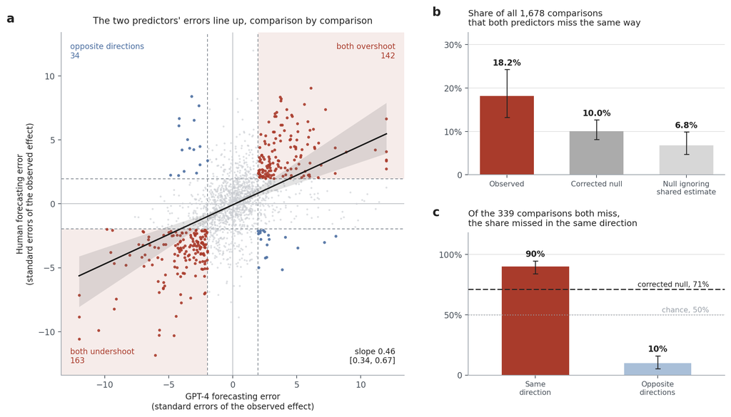

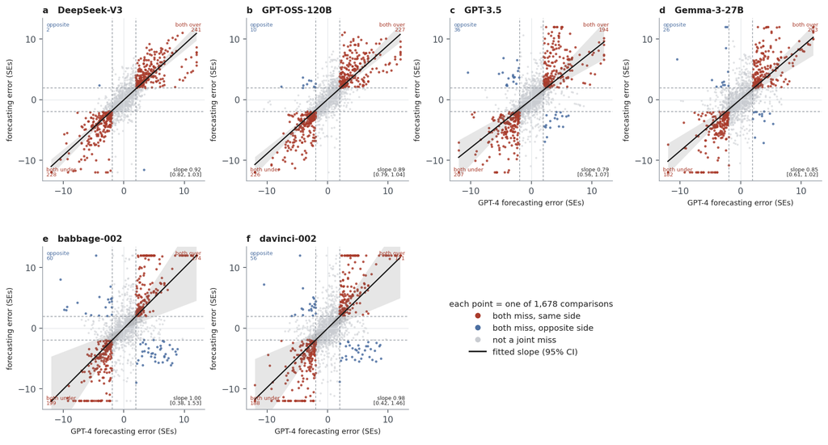

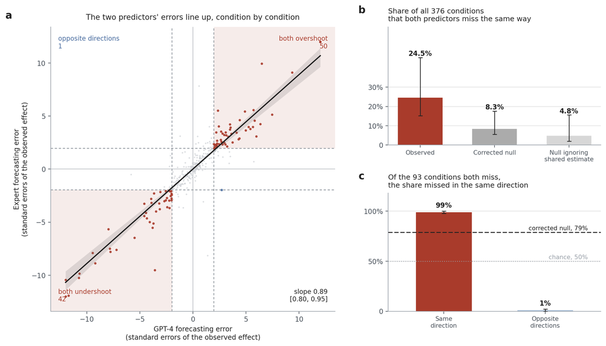

```r
for (f in c("fig1.png", "fig2.png", "fig3.png")) {
  p <- file.path(OUTDIR, f)
  if (file.exists(p)) cat(sprintf("![](%s)\n\n", p))
}
```

# Verification ledger

Every number quoted in the manuscript and its Supplementary Information, against the value computed in this render. `rule = round` requires the computed value to equal the quoted one at the quoted precision; `rule = leq` requires the computed value (a P value bounded by simulation resolution) to lie at or below the quoted bound; `rule = signif` compares at two significant digits. Rows that require the raw capsule files are checked only when those are present. **If any row fails, the render stops here.**

```r
rows <- list()
row <- function(section, quantity, quoted, value, digits = 3, rule = "round") {
  rows[[length(rows) + 1]] <<- tibble(section = section, quantity = quantity,
                                      quoted = quoted, computed = as.numeric(value),
                                      digits = digits, rule = rule)
}

## --- Main text ---
row("Main text", "GPT-4 miss rate (recalibrated)", 0.357, mean(miss_g))
row("Main text", "crowd miss rate (recalibrated)", 0.380, mean(miss_h))
row("Main text", "GPT-4 miss rate (unrecalibrated)", 0.463, mean(abs(wide$zg_raw) > 1.96))
row("Main text", "crowd miss rate (unrecalibrated)", 0.498, mean(abs(wide$zh_raw) > 1.96))
row("Main text", "joint misses (n)", 339, sum(joint), 0)
row("Main text", "joint-miss rate", 0.202, mean(joint))
row("Main text", "same-side misses (n)", 305, sum(same), 0)
row("Main text", "same-side rate", 0.182, mean(same))
row("Main text", "direction share | joint miss", 0.90, sum(same) / sum(joint), 2)
row("Main text", "combined recovers | opposite-side miss", 0.82, comb[["recovers_opposite_side"]], 2)
row("Main text", "combined still outside | same-side miss", 0.95, comb[["still_outside_same_side"]], 2)
row("Main text", "corrected null: joint rate", 0.141, ne[["joint"]])
row("Main text", "corrected null: same-side rate", 0.100, ne[["same"]])
row("Main text", "corrected null: direction share", 0.712, ne[["direction"]])
row("Main text", "naive null: same-side rate", 0.068, mean(miss_g) * mean(miss_h) / 2)
row("Main text", "studies with a joint miss", 46, n_distinct(wide$study[joint]), 0)
row("Main text", "same-side rate | larger effects", 0.279, conc_big[["inside"]])
row("Main text", "same-side rate | smaller effects", 0.103, conc_big[["outside"]])
row("Main text", "screening cell size", 75, sum(cell), 0)
row("Main text", "same-side rate inside screening cell", 0.56, conc_cell[["inside"]], 2)
row("Main text", "same-side rate outside screening cell", 0.164, conc_cell[["outside"]])
row("Main text", "share of same-side misses erring toward zero", 0.82, toward_zero, 2)
row("Main text", "crowd-on-GPT-4 error slope", 0.46, sb1$slope, 2)
row("Main text", "expert miss rate (secondary archive)", 0.319, mean(em2))
row("Main text", "GPT-4 miss rate (secondary archive)", 0.303, mean(gm2))
row("Main text", "experts also miss | GPT-4 miss", 0.816, sum(both2) / sum(gm2))
row("Main text", "same side | both miss (secondary)", 0.989, sum(same2) / sum(both2))
row("Main text", "expert-on-GPT-4 error slope", 0.89, sb2$slope, 2)

## --- Supplementary Methods ---
row("SI 1.2", "comparisons in the primary analysis", 1678, nrow(wide), 0)
row("SI 1.2", "studies", 70, n_distinct(wide$study), 0)
row("SI 1.2", "study-outcome combinations", 129,
    wide %>% distinct(study, outcome.name) %>% nrow(), 0)
row("SI 1.3", "pooled recalibration slope, GPT-4", 0.55,
    recal_lines$estimate[recal_lines$model == "gpt-4" & recal_lines$term == "slope"], 2)
row("SI 1.3", "pooled recalibration slope, crowd", 0.62,
    recal_lines$estimate[recal_lines$model == "human" & recal_lines$term == "slope"], 2)
row("SI 1.4", "same-side null, Student t(3) (%)", 9.6, tails["Student t(3)", "same"], 1)
row("SI 1.4", "same-side null, empirical (%)", 9.5, tails["empirical", "same"], 1)
row("SI 1.5", "study-specific null: joint rate", 0.160, ss_rates[["joint"]])
row("SI 1.5", "study-specific null: same-side rate", 0.103, ss_rates[["same_side"]])
row("SI 1.5", "study-specific null: direction share", 0.642, ss_rates[["direction"]])
row("SI 1.6", "bootstrap CI, joint rate, lower", 0.149, boot_ci[1, "joint"])
row("SI 1.6", "bootstrap CI, joint rate, upper", 0.264, boot_ci[2, "joint"])
row("SI 1.6", "bootstrap CI, same-side rate, lower", 0.134, boot_ci[1, "same"])
row("SI 1.6", "bootstrap CI, same-side rate, upper", 0.239, boot_ci[2, "same"])
row("SI 1.6", "bootstrap CI, direction share, lower", 0.841, boot_ci[1, "dir"])
row("SI 1.6", "bootstrap CI, direction share, upper", 0.949, boot_ci[2, "dir"])
row("SI 1.7", "P, joint rate vs corrected null", 1e-4, p_mc[["joint"]], rule = "leq")
row("SI 1.7", "P, same-side rate vs corrected null", 1e-4, p_mc[["same_side"]], rule = "leq")
row("SI 1.7", "P, direction share vs corrected null", 1e-4, p_mc[["direction"]], rule = "leq")
row("SI 1.7", "P, joint rate vs study-specific null", 5e-4, p_ss[["joint"]], rule = "leq")
row("SI 1.7", "P, same-side rate vs study-specific null", 5e-4, p_ss[["same_side"]], rule = "leq")
row("SI 1.7", "P, direction share vs study-specific null", 5e-4, p_ss[["direction"]], rule = "leq")
row("SI 1.7", "bootstrap P, joint rate", 0.010, p_boot[["joint"]], 3)
row("SI 1.7", "bootstrap P, same-side rate", 5e-4, p_boot[["same_side"]], 4)
row("SI 1.7", "bootstrap P, direction share", 2.5e-4, p_boot[["direction"]], rule = "leq")

## --- Supplementary Results ---
row("SI 2.1", "no recalibration: joint rate", 0.276, rob$joint[rob$analysis == "no recalibration"])
row("SI 2.1", "no recalibration: same-side rate", 0.209, rob$same_side[rob$analysis == "no recalibration"])
row("SI 2.1", "error correlation, pp scale, recalibrated", 0.59,
    cor(wide$zg * wide$std.error, wide$zh * wide$std.error), 2)
row("SI 2.1", "error correlation, pp scale, unrecalibrated", 0.39,
    cor(wide$pg - wide$estimate, wide$ph - wide$estimate), 2)
row("SI 2.2", "study-weighted joint rate", 0.302, mean(by_study$joint))
row("SI 2.2", "study-weighted same-side rate", 0.248, mean(by_study$same))
row("SI 2.2", "authors' scheme, 32 draws: joint", 0.205, median(draws32[, "joint"]))
row("SI 2.2", "authors' scheme, 32 draws: same-side", 0.183, median(draws32[, "same"]))
row("SI 2.2", "authors' scheme, 500 draws: joint", 0.209, median(draws500[, "joint"]))
row("SI 2.2", "authors' scheme, 500 draws: same-side", 0.183, median(draws500[, "same"]))
row("SI 2.2", "comparisons per draw (median)", 469, median(draws32[, "n"]), 0)
row("SI 2.2", "s.d. across draws, same-side", 0.021, sd(draws500[, "same"]))
row("SI 2.3", "studies with a same-side miss", 43, n_distinct(wide$study[same]), 0)
row("SI 2.3", "slope CI lower (clustered by study)", 0.30, het_slope[["ci_lo"]], 2)
row("SI 2.3", "slope CI upper (clustered by study)", 0.62, het_slope[["ci_hi"]], 2)
row("SI 2.3", "co-error variance between studies (%)", 33.7, varshare, 1)
row("SI 2.3", "studies with >= 5 comparisons", 39, slope_sum[["n_studies"]], 0)
row("SI 2.3", "median per-study slope", 0.58, slope_sum[["median"]], 2)
row("SI 2.3", "per-study slope, 25th percentile", 0.28, slope_sum[["q25"]], 2)
row("SI 2.3", "per-study slope, 75th percentile", 0.97, slope_sum[["q75"]], 2)
row("SI 2.4", "observed mean co-error", 3.62, w_obs, 2)
row("SI 2.4", "permutation s.d.", 0.18, sd(w_perm), 2)
row("SI 2.4", "studies with positive mean co-error", 59, sum(per_study$w > 0), 0)
row("SI 2.4", "Spearman correlation of errors", 0.51,
    cor(wide$zg, wide$zh, method = "spearman"), 2)
row("SI 2.4", "Wilcoxon P (study level)", 5.6e-7, wilcox_p, 2, rule = "signif")
for (i in seq_len(nrow(cross_template))) {
  row("SI 2.5", paste0(cross_template$predictor[i], ": repeats same direction"),
      c(0.78, 0.76, 0.67, 0.64, 0.62, 0.60, 0.51)[i], cross_template$also_same_side[i], 2)
  row("SI 2.5", paste0(cross_template$predictor[i], ": error correlation"),
      c(0.82, 0.79, 0.65, 0.67, 0.57, 0.57, 0.50)[i], cross_template$error_corr[i], 2)
}
row("SI 2.5", "crowd corrected-null benchmark", 0.28,
    cross_template$null_also_same[cross_template$predictor == "human"], 2)
row("SI 2.6", "secondary archive: treatment effects", 606, a2_total[["effects_total"]], 0)
row("SI 2.6", "secondary archive: megastudies", 15, a2_total[["megastudies"]], 0)
row("SI 2.6", "conditions with expert forecasts", 376, nrow(a2), 0)
row("SI 2.6", "null: experts also miss | GPT-4 miss", 0.347, n2[["joint"]] / mean(gm2))
row("SI 2.6", "null: same side | both miss", 0.789, n2[["direction"]])
row("SI 2.6", "same-direction rate, all conditions", 0.245, sum(same2) / nrow(a2))
row("SI 2.6", "null same-direction rate", 0.083, n2[["same"]])
row("SI 2.6", "naive same-direction rate", 0.048, mean(gm2) * mean(em2) / 2)
row("SI 2.6", "expert slope CI lower (clustered)", 0.85, arch2_slope[["ci_lo"]], 2)
row("SI 2.6", "expert slope CI upper (clustered)", 0.93, arch2_slope[["ci_hi"]], 2)
row("SI 2.7", "comparisons with larger effects", 752, sum(big), 0)
row("SI 2.7", "comparisons with smaller effects", 926, sum(!big), 0)
row("SI 2.7", "corrected null, larger effects", 0.150,
    null_exact(mean(miss_g[big]), mean(miss_h[big]))[["same"]])
row("SI 2.7", "corrected null, smaller effects", 0.066,
    null_exact(mean(miss_g[!big]), mean(miss_h[!big]))[["same"]])
row("SI 2.7", "corrected null, screening cell", 0.222,
    null_exact(mean(miss_g[cell]), mean(miss_h[cell]))[["same"]])
row("SI 2.8", "same-side rate, threshold 3.29", 0.066, ab329[["same_side"]])
row("SI 2.8", "calibration cap, 1.96", 0.05, ab196[["cap"]])
row("SI 2.8", "calibration cap, 3.29", 0.001, ab329[["cap"]])
row("SI 2.8", "observed / cap, 3.29", 65.4, ab329[["ratio"]], 1)
row("SI 2.8", "floor share, expectation, 1.96", 0.725, ab196[["floor_expect"]])
row("SI 2.8", "floor share, expectation, 3.29", 0.985, ab329[["floor_expect"]])
row("SI 2.8", "floor share, binomial cap, 1.96", 0.666, ab196[["floor_binom"]])
row("SI 2.8", "floor share, binomial cap, 3.29", 0.955, ab329[["floor_binom"]])
row("SI 2.8", "floor share, tenfold miscalibration, 3.29", 0.847, ab329[["floor_tenfold"]])

## --- Raw-data counts (checked only when the capsule is present) ---
if (capsule_present) {
  row("SI 1.1", "individual responses", 233601, sum(map_int(rct$data, nrow)), 0)
  row("SI 1.1", "non-missing responses", 229154, sum(map_int(rct$data, ~sum(!is.na(.x$y)))), 0)
  row("SI 1.1", "studies in the raw archive", 71, n_distinct(rct$study), 0)
  row("SI 1.1", "study-outcome cells in the raw archive", 134, nrow(rct), 0)
  row("SI 1.1", "language-model responses", 504840, nrow(llm), 0)
  row("SI 1.1", "responses per model", 72120, nrow(llm) / n_distinct(llm$model), 0)
  row("SI 1.1", "human forecasts", 18317, nrow(fc), 0)
  row("SI 1.1", "forecasters", 2838, n_distinct(fc$PROLIFIC_PID), 0)
  row("SI 1.2", "possible comparisons", 1705,
      rct %>% pmap_int(function(data, ...) {
        k <- n_distinct(data$condition.name)
        as.integer(k * (k - 1) / 2) }) %>% sum(), 0)
}

led <- bind_rows(rows) %>%
  mutate(ok = case_when(
    rule == "round"  ~ abs(round(computed, digits) - quoted) < 1e-9,
    rule == "leq"    ~ computed <= quoted,
    rule == "signif" ~ abs(signif(computed, digits) - quoted) < 1e-12))

led %>%
  transmute(Section = section, Quantity = quantity,
            Quoted   = format(quoted, scientific = FALSE, trim = TRUE, drop0trailing = TRUE),
            Computed = format(signif(computed, 6), scientific = FALSE,
                              trim = TRUE, drop0trailing = TRUE),
            Rule = rule, Match = ifelse(ok, "ok", "FAIL")) %>%
  knitr::kable(align = c("l", "l", "r", "r", "l", "l"))
```

| Section | Quantity | Quoted | Computed | Rule | Match |
| --- | --- | --- | --- | --- | --- |
| Main text | GPT-4 miss rate (recalibrated) | 0.357 | 0.356973 | round | ok |
| Main text | crowd miss rate (recalibrated) | 0.38 | 0.380215 | round | ok |
| Main text | GPT-4 miss rate (unrecalibrated) | 0.463 | 0.463051 | round | ok |
| Main text | crowd miss rate (unrecalibrated) | 0.498 | 0.498212 | round | ok |
| Main text | joint misses (n) | 339 | 339 | round | ok |
| Main text | joint-miss rate | 0.202 | 0.202026 | round | ok |
| Main text | same-side misses (n) | 305 | 305 | round | ok |
| Main text | same-side rate | 0.182 | 0.181764 | round | ok |
| Main text | direction share \| joint miss | 0.9 | 0.899705 | round | ok |
| Main text | combined recovers \| opposite-side miss | 0.82 | 0.823529 | round | ok |
| Main text | combined still outside \| same-side miss | 0.95 | 0.954098 | round | ok |
| Main text | corrected null: joint rate | 0.141 | 0.140889 | round | ok |
| Main text | corrected null: same-side rate | 0.1 | 0.100269 | round | ok |
| Main text | corrected null: direction share | 0.712 | 0.711692 | round | ok |
| Main text | naive null: same-side rate | 0.068 | 0.0678631 | round | ok |
| Main text | studies with a joint miss | 46 | 46 | round | ok |
| Main text | same-side rate \| larger effects | 0.279 | 0.279255 | round | ok |
| Main text | same-side rate \| smaller effects | 0.103 | 0.102592 | round | ok |
| Main text | screening cell size | 75 | 75 | round | ok |
| Main text | same-side rate inside screening cell | 0.56 | 0.56 | round | ok |
| Main text | same-side rate outside screening cell | 0.164 | 0.164067 | round | ok |
| Main text | share of same-side misses erring toward zero | 0.82 | 0.822951 | round | ok |
| Main text | crowd-on-GPT-4 error slope | 0.46 | 0.462822 | round | ok |
| Main text | expert miss rate (secondary archive) | 0.319 | 0.319149 | round | ok |
| Main text | GPT-4 miss rate (secondary archive) | 0.303 | 0.303191 | round | ok |
| Main text | experts also miss \| GPT-4 miss | 0.816 | 0.815789 | round | ok |
| Main text | same side \| both miss (secondary) | 0.989 | 0.989247 | round | ok |
| Main text | expert-on-GPT-4 error slope | 0.89 | 0.890658 | round | ok |
| SI 1.2 | comparisons in the primary analysis | 1678 | 1678 | round | ok |
| SI 1.2 | studies | 70 | 70 | round | ok |

[output cut: 96 more lines]

```r
if (!all(led$ok)) {
  print(filter(led, !ok))
  stop("Verification failed: ", sum(!led$ok),
       " quoted value(s) did not reproduce. See the rows printed above.")
}
cat(sprintf("\nAll %d quoted values reproduce%s.\n", nrow(led),
            if (capsule_present) "" else
            " (raw-data counts not checked: capsule files not present)"))
```

```
##
## All 126 quoted values reproduce.
```